# Dimensiereductie

Auteurs: Brian van der Bijl (brian.vanderbijl@hu.nl), Tijmen Muller

- Studentnummer: 1853447
- Naam: Dominik Enzinger
- Datum: 3/2/2026

## Deel I: Principal Component Analysis (PCA)

Het *Principal Component Analysis* (PCA) algoritme kan gebruikt worden om het aantal dimensies van een dataset te reduceren tot de belangrijkste componenten. Als de originele dataset $n$ dimensies heeft, dan kunnen we met onderstaande stappen dit terugbrengen tot een (zelfgekozen) aantal van $n^\prime$ dimensies.

1. Centreer de data.
2. Bereken de covariantie van alle features onderling.
3. Bereken de Eigenvectors en Eigenvalues van de covariantiematrix.
4. Kies de $n^\prime$ Eigenvectors om de dimensiereductie mee uit te voeren.
5. Vermenigvuldig de $n^\prime$ Eigenvectors met de originele data om de reductie toe te passen.

### Context

Gegeven is een databestand met embeddings van 200 tekstfragmenten. Elke embedding bestaat in 15 dimensies, en is gelabeled met een categorie. We gaan dimensionaliteitsreductie toepassen om de data te kunnen plotten.

De categorie geeft aan in welk genre de tekstfragmenten thuishoren. Daarnaast is onderscheid gemaakt tussen het perspectief waarin het fragment geschreven is: ik (1st person) of hij/haar/hen (3rd person):

- Fantasy (1st person)
- Fantasy (3rd person)
- Science Fiction (1st person)
- Science Fiction (3rd person)
- Romance (1st person)
- Romance (3rd person)
- Crime (1st person)
- Crime (3rd person)

```python
import numpy as np
import pickle
import matplotlib.pyplot as plt
from matplotlib import colormaps
from sklearn.manifold import TSNE

# Show floats on 3 digits, suppress scientific notation
np.set_printoptions(precision=3, suppress=True)
```

```python
with open('data.pkl', 'rb') as file:
    data = pickle.load(file)

data.head(5)
```

shape: (5, 16)

| e_1 f64 | e_2 f64 | e_3 f64 | e_4 f64 | e_5 f64 | e_6 f64 | e_7 f64 | e_8 f64 | e_9 f64 | e_10 f64 | e_11 f64 | e_12 f64 | e_13 f64 | e_14 f64 | e_15 f64 | label str |
| --- | --- | --- | --- | --- | --- | --- | --- | --- | --- | --- | --- | --- | --- | --- | --- |
| 1.108966 | 0.827991 | 1.627138 | 0.925778 | 0.945613 | 3.722442 | 0.457359 | 2.669865 | 0.805594 | 1.061672 | 0.762532 | 1.0722 | 0.539163 | 0.620247 | 0.380938 | "Fantasy (1st person)" |
| 1.653362 | 1.554929 | 1.475294 | 0.677498 | 1.302392 | 3.866261 | 0.804821 | 3.102261 | 1.228692 | 0.793275 | 0.338367 | 1.633079 | 1.049915 | 1.0656 | 0.299805 | "Fantasy (1st person)" |
| 1.225105 | 1.216584 | 1.423586 | 1.248953 | 0.965199 | 3.774443 | 0.491922 | 2.882402 | 1.151147 | 0.659875 | 0.285644 | 1.344977 | 1.0466 | 1.127903 | 0.689821 | "Fantasy (1st person)" |
| 1.732045 | 1.577317 | 1.555516 | 1.323991 | 1.093897 | 3.89912 | 0.153112 | 2.815527 | 1.318954 | 0.530422 | 0.866516 | 1.354425 | 0.503422 | 0.952766 | 0.185922 | "Fantasy (1st person)" |
| 1.2672 | 1.169387 | 0.949254 | 0.692989 | 1.048017 | 3.948163 | 0.512988 | 3.215607 | 1.02247 | 0.983851 | 0.886414 | 1.369123 | 0.383284 | 0.710478 | 0.572426 | "Fantasy (1st person)" |

### Voorbereidende opdracht

Gegeven een dataset met $m$ datapunten met elk $n$ features en een gewenste reductie tot $n^\prime$ dimensies. Bepaal voor elk van de vijf stappen van het algoritme wat de dimensies (oftewel `shape`) is van de volgende tussenresultaten:

1. De matrix met de originele dataset.
2. De matrix met de gemiddelden per feature om de data mee te centreren.
3. De covariantiematrix.
4. De matrix met de Eigenvectors en de matrix met de Eigenvalues.
5. De matrix met de *geselecteerde* Eigenvectors.
6. De matrix met de *gereduceerde* data.

**Antwoorden:**

Ik heb een aantal prints in de PCA-functie gezet om te laten zien wat de dimensies van de matrices zijn tijdens het doorlopen van de stappen van PCA. Verder heb ik ook in de prints gezet waarvan elke dimensie afhangt (datapunten, features, n_components).

**1. De matrix met de originele dataset.**

Het aantal dimensies van de originele dataset hangt af van het aantal datapunten en het aantal features; dus $D^{m \times n}$ of $D^{n \times m}$

**2. De matrix met de gemiddelden per feature om de data mee te centreren.**

Het aantal dimensies van de matrix met de gemiddelden per feature wordt bepaald door het aantal dimensies van de originele dateset. Om van elke waarde in de dataset het gemiddelde af te kunnen halen kunnen we een matrix gebruiken met het gemiddelde van elke feature (rij of kolom; afhankelijk van het format); dus $D^{m \times n}$ of $D^{n \times m}$

We zouden ook een vector kunnen gebruiken en de vector met shape $D^{n \times 1}$ broadcasten over de matrix. (Dit is ook wat numpy doet.)

**3. De covariantiematrix.**

Het aantal dimensies van de covariantiematrix is afhankelijk van het aantal features, omdat we elke feature met elke andere feature willen vergelijken; dus $D^{n \times n}$

**4. De matrix met de Eigenvectors en de matrix met de Eigenvalues.**

De matrix met de eigenvectors is even groot als de covariantiematrix, omdat de covariantiematrix symetrisch is zijn er het maximale aantal eigenvectors; dus $D^{n \times n}$  
De vector met de eigenvalues heeft het zelfde aantal dimensies als het aantal features; dus $D^{n \times 1}$

**5. De matrix met de *geselecteerde* Eigenvectors.**

Het aantal dimensies van de geselcteerde eigenvectors hangt af van het aantal eigenvectors die behouden blijven en het aantal features; dus $D^{n' \times n}$ of $D^{n \times n'}$

**6. De matrix met de *gereduceerde* data.**

Het aantal dimensies van de gereduceerde data is afhankelijk van het aantal gekozen eigenvectors en het aantal datapunten; dus $D^{m \times n'}$ of $D^{n' \times m}$

### Opdracht 1. Implementatie

Schrijf een eigen implementatie van het PCA-algoritme `compute_pca(X, n_components)` volgens eerdergenoemde stappen van het algoritme. Maak slim gebruik van fucties van `numpy` waar mogelijk, maar zorg wel dat je begrijpt wat je in elke stap doet. De laatste stap is al gegeven in de functiedefinitie hieronder.

Hint: Laat bij stap 3. zien (bijvoorbeeld met een `print()` statement) dat de meest informatieve Eigenvalue al meer dan 50% van de informatie bevat van onze dataset.

#### Input

- `X: numpy.array` - numpy matrix met dimensies $(m, n)$; elke rij is een datapunt in $n$ dimensies
- `n_components: int` - het gewenste aantal dimensies $n^\prime$

#### Output

`X_reduced: numpy.array` - een $(m, n^\prime)$ numpy matrix met de gereduceerde data.

```python
def compute_pca(X, n_components, prints=False, print_kept_information=False):
    """
    Parameters
    ----------
    X : numpy.ndarray
        Input data matrix of shape (m, n), where m is the number of samples and n is the number of features.
    n_components : int
        The number of principal components (dimensions) to keep.
    prints : boolean
        Whether or not to print the pca process.
    print_kept_information : boolean
        Wheter or not the factor (percentage) of kept information is printed.

    Returns
    -------
    X_reduced : numpy.ndarray
        The data projected onto the top n_components principal components.
    """
    matrix = np.array(X)

    # Step 1: Center or normalize the matrix
    centered_data = matrix - matrix.mean(axis=0)  # axis 0 is the vertical axis, thus mean/ of each column.
    # normalized_data = (matrix - matrix.mean(axis=0)) / matrix.std(axis=0)  # We could also normalize the data

    # Step 2: Calculate the covariance matrix
    covariance_matrix = np.cov(centered_data, rowvar = False)

    # Step 3: Calculate eigenvalues and eigenvectors
    eigenvalues, eigenvectors = np.linalg.eigh(covariance_matrix)
    sorting_helper = np.argsort(eigenvalues)[::-1]
    sorted_eigenvalues = eigenvalues[sorting_helper]
    sorted_eigenvectors = eigenvectors[:,sorting_helper]
    eigenvalue_information = sorted_eigenvalues / sum(sorted_eigenvalues)

    # Step 4: Select eigenvectors (pc's, principal components) to keep
    selected_eigenvectors = sorted_eigenvectors[:,:n_components]
    kept_information = np.sum(eigenvalue_information[:n_components])

    # Prints:
    if prints:
        print("Data matrix shape (datapoints, features):", matrix.shape, sep="\n", end="\n\n")
        print("Data matrix:", matrix, sep="\n", end="\n\n")
        print("Mean vector shape (features, 1):", matrix.mean(axis=0).shape, sep="\n", end="\n\n")
        print("Mean vector -> getting broadcast:", matrix.mean(axis=0), sep="\n", end="\n\n")
        print("Centered data shape (datapoints, features):", centered_data.shape, sep="\n", end="\n\n")
        print("Centered Data:", centered_data, sep="\n", end="\n\n")
        print("Covariance matrix shape (features, features):", covariance_matrix.shape, sep="\n", end="\n\n")
        print("Covariance matrix:", covariance_matrix, sep="\n", end="\n\n")
        print("Eigenvalues shape (features, 1):", eigenvalues.shape, sep="\n", end="\n\n")
        print("Eigenvalues:", eigenvalues, sep="\n", end="\n\n")
        print("Eigenvectors shape (features, features):", eigenvectors.shape, sep="\n", end="\n\n")
        print("Eigenvectors:", eigenvectors, sep="\n", end="\n\n")
        print("Sorting helper (indices):", sorting_helper, sep="\n", end="\n\n")
        print("Sorted eigenvalues shape (features, 1):", sorted_eigenvalues.shape, sep="\n", end="\n\n")
        print("Sorted eigenvalues:", sorted_eigenvalues, sep="\n", end="\n\n")
        print("Eigenvalue information (percentage of information of each eigenvalue/eigenvector):", eigenvalue_information, sep="\n", end="\n\n")
        print("Sorted eigenvectors shape (features, features):", sorted_eigenvectors.shape, sep="\n", end="\n\n")
        print("Sorted eigenvectors:", sorted_eigenvectors, sep="\n", end="\n\n")
        print("Selected eigenvectors shape (features, n_components):", selected_eigenvectors.shape, sep="\n", end="\n\n")
        print("Selected eigenvectors:", selected_eigenvectors, sep="\n", end="\n\n")
        print("Kept information:", kept_information, sep="\n", end="\n\n")
        print("Result shape (datapoints, n_components):", (centered_data @ selected_eigenvectors).shape, sep="\n", end="\n\n")
        print("Result:", centered_data @ selected_eigenvectors, sep="\n", end="\n\n")
    if print_kept_information:
        print("Kept information:", kept_information, sep="\n", end="\n\n")

    # Stap 5: Multiply chosen eigenvectors with the centered or normalized dataset.
    return centered_data @ selected_eigenvectors
```

#### Test-scenario

Onderstaande code zou de volgende output moeten opleveren (het minteken kan wisselen):

```
[[ 0.43437323 -0.49820384]
 [ 0.42077249  0.50351448]
 [-0.85514571 -0.00531064]]
```

```python
np.random.seed(1)
X = np.random.rand(3, 10)
X_reduced = compute_pca(X, n_components=2, prints=True, print_kept_information=False)
```

```
Data matrix shape (datapoints, features):
(3, 10)

Data matrix:
[[0.417 0.72  0.    0.302 0.147 0.092 0.186 0.346 0.397 0.539]
 [0.419 0.685 0.204 0.878 0.027 0.67  0.417 0.559 0.14  0.198]
 [0.801 0.968 0.313 0.692 0.876 0.895 0.085 0.039 0.17  0.878]]

Mean vector shape (features, 1):
(10,)

Mean vector -> getting broadcast:
[0.546 0.791 0.173 0.624 0.35  0.552 0.23  0.314 0.236 0.538]

Centered data shape (datapoints, features):
(3, 10)

Centered Data:
[[-0.129 -0.071 -0.173 -0.322 -0.203 -0.46  -0.043  0.031  0.161  0.   ]
 [-0.126 -0.106  0.032  0.254 -0.323  0.118  0.188  0.244 -0.095 -0.34 ]
 [ 0.255  0.177  0.141  0.068  0.526  0.342 -0.144 -0.275 -0.066  0.34 ]]

Covariance matrix shape (features, features):
(10, 10)

Covariance matrix:
[[ 0.049  0.034  0.027  0.013  0.101  0.066 -0.028 -0.053 -0.013  0.065]
 [ 0.034  0.024  0.017  0.004  0.071  0.04  -0.021 -0.038 -0.006  0.048]
 [ 0.027  0.017  0.025  0.037  0.049  0.066 -0.003 -0.018 -0.02   0.018]
 [ 0.013  0.004  0.037  0.086  0.01   0.101  0.026  0.017 -0.04  -0.032]
 [ 0.101  0.071  0.049  0.01   0.211  0.118 -0.064 -0.115 -0.018  0.144]
 [ 0.066  0.04   0.066  0.101  0.118  0.171 -0.004 -0.04  -0.054  0.038]
 [-0.028 -0.021 -0.003  0.026 -0.064 -0.004  0.029  0.042 -0.008 -0.057]
 [-0.053 -0.038 -0.018  0.017 -0.115 -0.04   0.042  0.068 -0.    -0.088]
 [-0.013 -0.006 -0.02  -0.04  -0.018 -0.054 -0.008 -0.     0.02   0.005]
 [ 0.065  0.048  0.018 -0.032  0.144  0.038 -0.057 -0.088  0.005  0.116]]

Eigenvalues shape (features, 1):
(10,)

```

[output cut: 55 more lines]

```
 [ 0.168 -0.233]
 [ 0.321 -0.217]
 [ 0.079  0.255]
 [-0.395  0.345]]

Kept information:
1.0

Result shape (datapoints, n_components):
(3, 2)

Result:
[[ 0.434  0.498]
 [ 0.421 -0.504]
 [-0.855  0.005]]
```

### Opdracht 2. Visualisatie met dimensiereductie

Maak op basis van de aangeleverde `data` een numpy array van de datapunten, en gebruik je PCA-implementatie om een 2D- en 3D-weergave van de data te maken. Maak van elke weergave een plot, waarbij iedere categorie een eigen kleur krijgt.

```python
# Convert labers to numbers (necessary for the color map)
labels_to_numbers = {"Fantasy (1st person)" : 1,
                     "Fantasy (3rd person)" : 2,
                     "Science Fiction (1st person)" : 3,
                     "Science Fiction (3rd person)" : 4,
                     "Romance (1st person)" : 5,
                     "Romance (3rd person)" : 6,
                     "Crime (1st person)" : 7,
                     "Crime (3rd person)" : 8}

# Convert the labels into numbers (for scatter plot color map)
color_labels = data[:,-1].replace_strict(labels_to_numbers)

# Define categories (for the legends of the plots)
categories = ["Fantasy (1st person)", "Fantasy (3rd person)", "Science Fiction (1st person)", "Science Fiction (3rd person)", "Romance (1st person)", "Romance (3rd person)", "Crime (1st person)", "Crime (3rd person)"]

# Separate matrix and labels
matrix = np.array(data[:,:-1])
```

```
Kept information:
0.6866656218830466
```

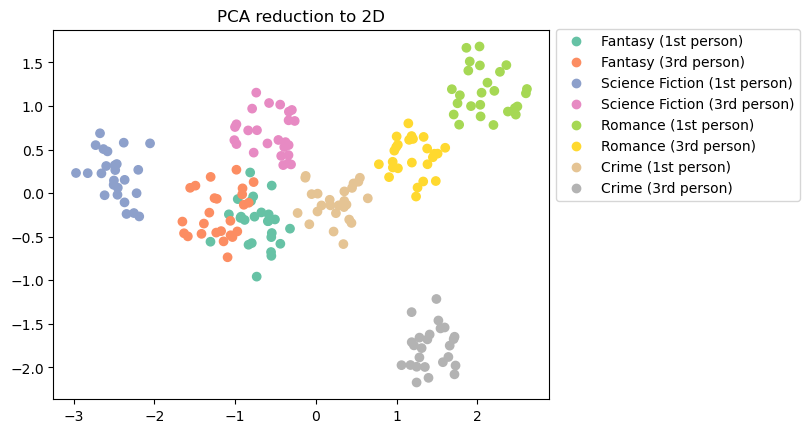

```python
reduced_to_2d = compute_pca(matrix, 2, False, True)

# Create 2D scatter plot
scatter_pca_2d = plt.scatter(reduced_to_2d[:,0], reduced_to_2d[:,1], c=color_labels, cmap="Set2")
plt.title("PCA reduction to 2D")
plt.legend(handles=scatter_pca_2d.legend_elements()[0], labels=categories, bbox_to_anchor=(1.0, 1.02))
```

```
Kept information:
0.7721763602652282
```

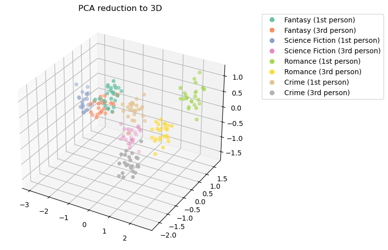

```python
reduced_to_3d = compute_pca(matrix, 3, False, True)

# Create a figure and 3D axis
fig = plt.figure(figsize=(8,6))
ax = fig.add_subplot(111, projection='3d')

# Create 3D scatter plot
scatter_pca_3d = ax.scatter3D(reduced_to_3d[:,0], reduced_to_3d[:,1], reduced_to_3d[:,2], c=color_labels, cmap="Set2", marker='o')
plt.title("PCA reduction to 3D")
plt.legend(handles=scatter_pca_3d.legend_elements()[0], labels=categories, bbox_to_anchor=(1.1, 1.02))
```

### Opdracht 3. Analyse

Analyseer de resultaten:

1. Welke categorieën zijn op basis van de PCA-reductie te onderscheiden, en welke niet?
2. Geef aan hoeveel procent van de informatie bewaard is gebleven in 2D en 3D respectievelijk.
3. Hoeveel dimensies zijn nodig om 90% van de informatie te bewaren?
4. En voor 95%?

**Antwoorden:**

**1. Welke categorieën zijn op basis van de PCA-reductie te onderscheiden, en welke niet?**

We kunnen in de plots zien welke categorieen goed van elkaar te scheiden zijn door te kijken of datapunten duidelijk geclusterd zijn of overlappen.  
Het is lastig om in de 3d plot te zien waar welke gebieden overlappen. Ik zal daarom de 2d plot gebruiken om een uitspraak over de gebieden te doen.

Goed te onderscheiden:

- Science fiction (1st person)
- Science fictioin (3rd person)
- Romance (1st person)
- Romance (3rd person)
- Crime (1st person)
- Crime (3rd person)

Minder goed te onderscheiden:

- Fantasy (1st person)
- Fantasy (3rd person)

Een andere manier om te bepalen of de categorieen goed te onderscheiden zijn is In-Class vs Out-Class Distance Calculation. (Euclidean distance, de norm (afstand) tussen twee punten).

**2. Geef aan hoeveel procent van de informatie bewaard is gebleven in 2D en 3D respectievelijk.**

- 2D: 0.6866656218830463
- 3D: 0.772176360265228

| Aantal Dimensies | Percentage | Cumulatieve Percentage |
| --- | --- | --- |
| 1 | 0.51 | 0.51 |
| 2 | 0.177 | 0.687 |
| 3 | 0.086 | 0.773 |
| 4 | 0.047 | 0.82 |
| 5 | 0.038 | 0.858 |
| 6 | 0.027 | 0.885 |
| 7 | 0.02 | 0.905 |
| 8 | 0.017 | 0.922 |
| 9 | 0.015 | 0.937 |
| 10 | 0.013 | 0.95 |
| 11 | 0.013 | 0.963 |
| 12 | 0.011 | 0.974 |
| 13 | 0.01 | 0.984 |
| 14 | 0.009 | 0.993 |
| 15 | 0.009 | 1.002 |

Het resultaat voor het optellen van de percentages komt boven 1 (100%) uit. Dit is een gevolg van het afronden van de waardes.

**3. Hoeveel dimensies zijn nodig om 90% van de informatie te bewaren?**

- 7 (Zie tabel)

**4. En voor 95%?**

- 10 (Zie tabel)

## Deel II: t-Distributed Stochastic Neighbour Embedding (t-SNE)

Een alternatieve methode voor dimensiereductie is *t-Distributed Stochastic Neighbour Embedding* (t-SNE).

### Opdracht 4. Toepassing

Gebruik SciKit-Learn om met behulp van t-SNE de data tot 2 dimensies te reduceren en plot het resultaat (wederom met kleuren voor de categorien).

```python
def compute_tsne(X, n_components, perplexity):
    matrix = np.array(X)
    tsne = TSNE(n_components, perplexity=perplexity)  # perplexity: how many nearest neighbours are considered. (controls the sigma of the gaussian)
    tsne_result = tsne.fit_transform(matrix)
    return tsne_result
```

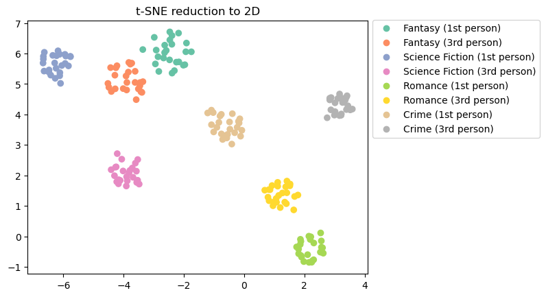

```python
tsne_2d = compute_tsne(matrix, 2, 70)

# Create 2D scatter plot
scatter_tsne_2d = plt.scatter(tsne_2d[:,0], tsne_2d[:,1], c=color_labels, cmap="Set2")
plt.title("t-SNE reduction to 2D")
plt.legend(handles=scatter_tsne_2d.legend_elements()[0], labels=categories, bbox_to_anchor=(1.0, 1.02))
```

### Opdracht 5. Vergelijking

Vergelijk deze met de resultaten van je PCA-implementatie:

1. Hoe verhoudt de zichtbaarheid van de categorieën zich tussen beide resultaten?
2. Hoe verhouden de algoritmes zich in het behoud van informatie?

Beantwoord de volgende vragen los van de data van deze opdracht:

3. Waarvoor zou je PCA en t-SNE inzetten als je te maken krijgt met een onbekende (mogelijk ongelabelde) dataset?
4. Geef een voorbeeld waar PCA de voorkeur heeft boven t-SNE.
5. Geef een voorbeeld waar t-SNE de voorkeur heeft boven PCA.

**Antwoorden:**

**1. Hoe verhoudt de zichtbaarheid van de categorieën zich tussen beide resultaten?**

t-SNE is in staat om de categorieen veel duidelijker van elkaar te scheiden. Dit komt omdat PCA alleen maar lineair kan scheiden, terwijl t-SNE ook niet lineair kan scheiden en de plek van de datapunten ten opzichte van elkaar verandert.

**2. Hoe verhouden de algoritmes zich in het behoud van informatie?**

*PCA:* Behoudt de spreiding van de datapunten (waar welk datapunt ten opzichte van elkaar staat blijft behouden).

*t-SNE:* Behoudt de proximiteit van de datapunten (waar welk datapunt ten opzichte van elkaar staat verandert, maar welke datapunten dicht bij elkaar liggen blijft behouden).

**3. Waarvoor zou je PCA en t-SNE inzetten als je te maken krijgt met een onbekende (mogelijk ongelabelde) dataset?**

*PCA:* Om te bepalen welke features de meeste invloed (informatie) op de meetpunten hebben en alleen de eigenvectoren te behouden die de meeste informatie bevatten. Hierdoor is het mogelijk de training-data te reduceren waardoor de vervolgstappen van het trainen van een ML-model efficienter worden; dus minder lang duren.

*t-SNE:* Om punten die dicht bij elkaar liggen binnen de dataset te clusteren en deze makkelijker te visualiseren.

**4. Geef een voorbeeld waar PCA de voorkeur heeft boven t-SNE.**

Omdat PCA veel sneller is dan t-SNE heeft PCA de voorkeur als een dataset heel groot is, en het dataset lineair te scheiden is. Verder is PCA deterministisch (het resultaat is altijd het zelfde), waardoor het de voorkeur heeft als het onderzoek reproduceerbaar moet zijn. Verder kan PCA worden gebruikt als datapreparatie stap voor het trainen van een model.

> Bijvoorbeeld een dataset van producten met:
> - feature1: de prijs
> - feature2: het aantal verkochte items

**5. Geef een voorbeeld waar t-SNE de voorkeur heeft boven PCA.**

In tegenstelling tot PCA is het met t-SNE mogelijk om clusters in niet lineaire data te vinden. t-SNE heeft dus de voorkeur om visualisaties van kleinere datasets te maken, waarbij er niet lineaire verbanden tussen de features bestaan.

> Bijvoorbeeld een dataset van gewichten aan veeren met:
> - feature1: de plaats van de het gewicht
> - feature2: de tijd

### Opdracht 6. Project

Als het goed is, heb je op dit moment een eerste idee van de data waar je in het project mee gaat werken. Geef antwoord op onderstaande vragen.

1. Wat is de dimensionaliteit waar je mee te maken hebt?
2. Beschrijf hoe dimensionaliteitsreductie-algoritmen je kunnen helpen de data te verkennen.

**Antwoorden:**

Ik heb helaas nog geen toegang tot de dataset van de opdrachtgever.